# Insurance Veri Madenciliği Projesi

# Grafikler

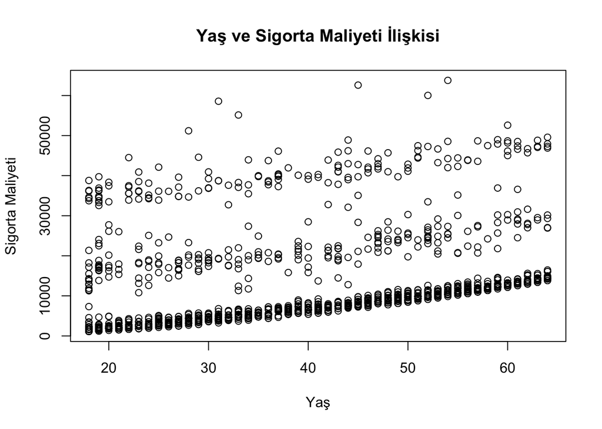

```r
plot(df$age, df$charges,
     main = "Yaş ve Sigorta Maliyeti İlişkisi",
     xlab = "Yaş",
     ylab = "Sigorta Maliyeti")
```

Bu grafik yaş ile sigorta maliyeti arasındaki ilişkiyi göstermektedir.

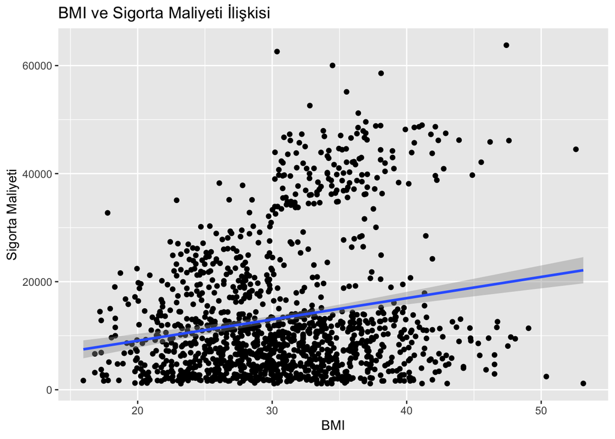

```r
ggplot(df, aes(x = bmi, y = charges)) +
  geom_point() +
  geom_smooth(method = "lm") +
  labs(title = "BMI ve Sigorta Maliyeti İlişkisi",
       x = "BMI",
       y = "Sigorta Maliyeti")
```

Bu grafik BMI ile sigorta maliyeti arasındaki ilişkiyi göstermektedir.

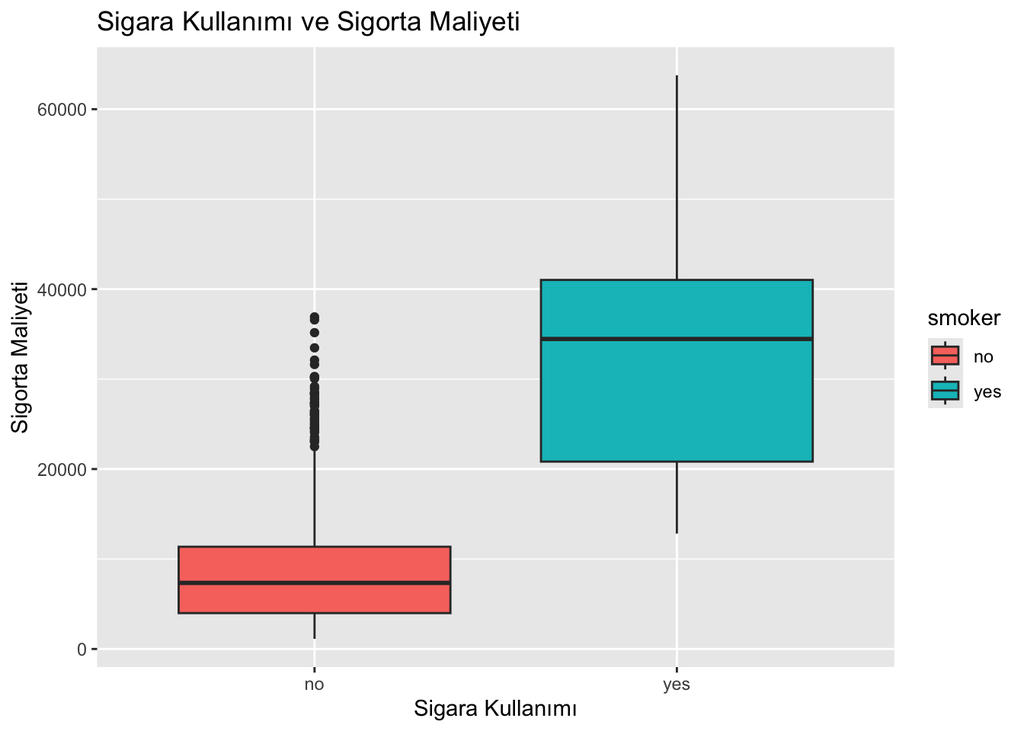

```r
ggplot(df, aes(x = smoker, y = charges, fill = smoker)) +
  geom_boxplot() +
  labs(title = "Sigara Kullanımı ve Sigorta Maliyeti",
       x = "Sigara Kullanımı",
       y = "Sigorta Maliyeti")
```

Bu grafik sigara kullanan ve kullanmayan bireylerin sigorta maliyet dağılımlarını göstermektedir.

# Sonuç

Bu projede insurance veri seti üzerinde veri madenciliği süreci uygulanmıştır. Projede önce veri seti incelenmiş, eksik veri ve aykırı değer kontrolleri yapılmış, değişken dönüşümleri gerçekleştirilmiş ve nihai veri seti oluşturulmuştur.

Analiz kapsamında:

- Korelasyon analizi,
- Basit doğrusal regresyon,
- Çoklu doğrusal regresyon,
- Model 3 ile sigorta maliyeti tahmini,
- Lojistik regresyon ile sigara içen / içmeyen tahmini,
- ROC eğrisi ve grafiksel analizler

yapılmıştır.

Sonuç olarak yaş, BMI, çocuk sayısı, sigara kullanımı ve bölge değişkenlerinin sigorta maliyeti üzerinde etkili olabileceği görülmüştür. Ayrıca lojistik regresyon ile bireyin sigara içme olasılığı 0-1 sınıflandırma mantığına göre analiz edilmiştir.